# Performing ANOVA in R

Jesse Wheeler

2026-09-04

## 1 Getting to Know the Data

Before running any models, it is crucial to understand the structure of your data.

```r
# Load the data
# CHECK YOUR FILE PATH!!!
resin <- read.csv('resin.csv')

colnames(resin)
```

```
## [1] "temperature" "time"
```

```r
dim(resin)
```

```
## [1] 37  2
```

```r
head(resin)
```

```
##   temperature time
## 1         175 2.04
## 2         175 1.91
## 3         175 2.00
## 4         175 1.92
## 5         175 1.85
## 6         175 1.96
```

R tries to figure out the correct thing to do based on data type. In our lectures on ANOVA, we focused on computing means of **treatment group**:

$$y_{ij} \sim N\big(\mu, \sigma^2\big) \quad \text{vs} \quad y_{ij} \sim N\big(\mu_i, \sigma^2\big)$$
For this data, our response $y_{ij}$ is the `time` variable, and the treatment is temperature.

**PROBLEM: temperature may be *numeric* type**

```r
class(resin$temperature)
```

```
## [1] "integer"
```

Because it is an `integer` type, R is going to treat this like a number for regression, **not** a treatment group / category. **This is a fairly common issue: treatment levels may be numbers, but we need to treat them like labels, not regression variables**.

**Solution: Convert to a `factor`**

```r
resin$temperature <- as.factor(resin$temperature)
class(resin$temperature)
```

```
## [1] "factor"
```

When a variable is a `factor` type, we can use the `table()` function to give categorical counts:

```r
table(resin$temperature)
```

```
##
## 175 194 213 231 250
##   8   8   8   7   6
```

The top row is the category (called a `level` in R), and the bottom row is the number of observations that are in that category, so we have $g = 5$ and

$$n_1 = 8, \, n_2 = 8, \, n_3 = 8, \, n_4 = 7, \, n_5 = 6$$

With the following treatment groups (`levels`):

```r
levels(resin$temperature)
```

```
## [1] "175" "194" "213" "231" "250"
```

## 2 Performing ANOVA with `aov()`

In class, we described ANOVA in terms of a few key quantities: Degrees of Freedom, Sum of Squares, and F-statistics, as summarized in the table below. This table represents a fairly generic ANOVA table, output that you would get in many different programing languages.

| Source | DF | SS | MS | F |
| --- | --- | --- | --- | --- |
| **Treatments** | $g - 1$ | $SS_{Trt}$ | $SS_{Trt}/(g - 1) = MS_{Trt}$ | $MS_{Trt} / MS_E$ |
| **Error** | $N - g$ | $SS_E$ | $SS_E/(N - g) = MS_E$ |  |

To get this table in R, we can use the `aov` function:

```r
# Run the built-in ANOVA function
model <- aov(time ~ temperature, data = resin)
summary(model)
```

```
##             Df Sum Sq Mean Sq F value Pr(>F)
## temperature  4  3.538  0.8844   96.36 <2e-16 ***
## Residuals   32  0.294  0.0092
## ---
## Signif. codes:  0 '***' 0.001 '**' 0.01 '*' 0.05 '.' 0.1 ' ' 1
```

**Why `as.factor()` is critical:** If your treatment levels are numeric (e.g., temperatures of 150, 175, 200), R will default to treating them as a continuous variable. It will attempt to fit a single regression line rather than estimating separate categorical group means ($\mu_i$). Wrapping the variable in `as.factor()` forces R to treat each temperature as a distinct, independent treatment group ($i = 1, \dots, g$).

## 3 Mapping the R Output to ANOVA Mechanics

Running `summary(model)` produces the classic ANOVA table. This table directly computes the Sum of Squares ($SS$) and Mean Squares ($MS$) used to compare the fit of the reduced model versus the full model.

| R Output Column | Slide Notation | Interpretation |
| --- | --- | --- |
| **Df** | $g-1$ and $N-g$ | Degrees of freedom for treatments and error, respectively. |
| **Sum Sq** | $SS_{Trt}$ and $SS_E$ | $SS_{Trt}$ (Temperature row) measures variance *between* group means. $SS_E$ (Residuals row) measures variance *within* groups. |
| **Mean Sq** | $MS_{Trt}$ and $MS_E$ | The Sum of Squares divided by their respective Degrees of Freedom. $MS_E$ is our unbiased estimate of the variance, $\hat{\sigma}^2$. |
| **F value** | $F$ | $MS_{Trt} / MS_E$. A larger $F$ indicates the separate means model explains significantly more variance than the single mean model. |
| **Pr(>F)** | $p$-value | The probability of seeing this $F$-statistic if the single mean model ($H_0: \alpha_i = 0$) were true. |

## 4 Estimating Parameters: Means and Treatment Effects

We have defined ANOVA using group means defined as: $\mu_i = \mu^* + \alpha_i$, where $\mu^*$ is the overall mean and $\alpha_i$ is the specific treatment effect. This is the **weighted average** approach, and it is also what is used by the R `aov` function.

### 4.1 Finding the Group Means ($\hat{\mu}_i$)

To find the separate group means ($\bar{y}_{i\bullet}$), we can aggregate the data:

```r
# Returns the mean 'time' for each 'temperature' group
tapply(resin$time, resin$temperature, mean)
```

```
##      175      194      213      231      250
## 1.932500 1.628750 1.377500 1.194286 1.056667
```

### 4.2 Finding the Treatment Effects ($\hat{\alpha}_i$)

By default, the `aov()` function paired with `model.tables()` uses the **weighted average** approach for the overall mean ($\hat{\mu}^* = \bar{y}_{\bullet\bullet}$), where $\sum n_i \hat{\alpha}_i = 0$.

```r
# Computes the estimated treatment effects (alpha_hat) for each group
model.tables(model, type = "effects")
```

```
## Tables of effects
##
##  temperature
##        175    194      213     231     250
##     0.4674 0.1636 -0.08764 -0.2708 -0.4085
## rep 8.0000 8.0000  8.00000  7.0000  6.0000
```

*Note on Reference Groups:* If you instead run `lm(time ~ as.factor(temperature))`, R defaults to the **Reference Group** parameterization ($\hat{\mu}^* = \bar{y}_{1\bullet}$). In that summary, the intercept is the mean of the first group, and the coefficients are the treatment effects ($\hat{\alpha}_i$) representing the difference between group $i$ and the first group.

## 5 Defining and Testing Contrasts

Aside from manual computations, there are a few ways that we can compute a contrast in R. We will use the `emmeans` (estimated marginal means) package, which is useful for analyzing experiments and computing contrasts.

```r
# Install if needed: install.packages("emmeans")
library(emmeans)

# Compute the estimated marginal means from the ANOVA model
emm <- emmeans(model, ~ temperature)

# Define the custom contrasts as a list of weight vectors
custom_contrasts <- list(
  "1 vs 2" = c(1, -1, 0, 0, 0),
  "2 vs 3" = c(0, 1, -1, 0, 0),
  "3 vs 4" = c(0, 0, 1, -1, 0),
  "Avg first 2 vs Avg last 3" = c(3/6, 3/6, -2/6, -2/6, -2/6) # Incorporates the divisor=6
)

# Test the contrasts
contrast(emm, method = custom_contrasts)
```

```
##  contrast                  estimate     SE df t.ratio p.value
##  1 vs 2                       0.304 0.0479 32   6.341  <.0001
##  2 vs 3                       0.251 0.0479 32   5.245  <.0001
##  3 vs 4                       0.183 0.0496 32   3.695  0.0008
##  Avg first 2 vs Avg last 3    0.571 0.0319 32  17.912  <.0001
```

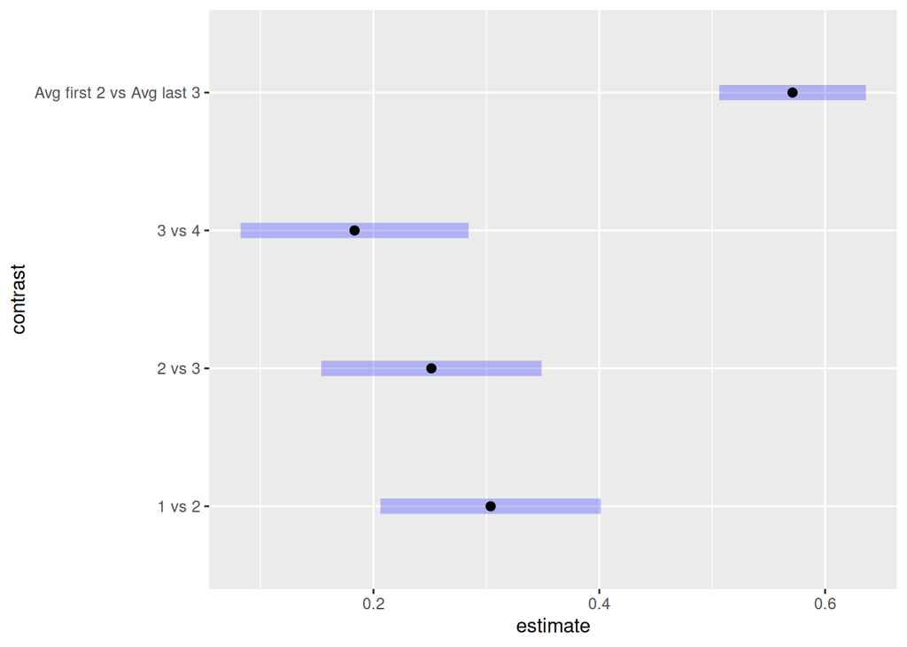

```r
plot(contrast(emm, method = custom_contrasts))
```

Note that computing one-sided confidence intervals and tests for contrasts is also possible. For instance:

```r
# Define the custom contrasts
custom_contrasts <- list(
  "1 vs 2" = c(1, -1, 0, 0, 0),
  "2 vs 3" = c(0, 1, -1, 0, 0)
)

# Create the contrast object
my_contrasts <- contrast(emm, method = custom_contrasts)

# Get one-sided Confidence Intervals (e.g., upper bound only, testing if < 0)
confint(my_contrasts, side = "<")
```

```
##  contrast estimate     SE df lower.CL upper.CL
##  1 vs 2      0.304 0.0479 32     -Inf    0.385
##  2 vs 3      0.251 0.0479 32     -Inf    0.332
##
## Confidence level used: 0.95
```

```r
# Get one-sided p-values for hypothesis testing
test(my_contrasts, side = "<")
```

```
##  contrast estimate     SE df t.ratio p.value
##  1 vs 2      0.304 0.0479 32   6.341  1.0000
##  2 vs 3      0.251 0.0479 32   5.245  1.0000
##
## P values are left-tailed
```

## 6 Adjusting for Multiple Comparisons

The ANOVA F-test is just the beginning, as it only tests the null hypothesis that all treatment means are exactly the same. Once we reject that null hypothesis, we naturally want to run contrasts to understand the specific pattern of differences.

However, doing this introduces the multiple testing problem. Every time we test a single contrast, we have a per comparison Type I error rate (typically $\alpha = 0.05$). If we test multiple contrasts simultaneously, the probability of making at least one Type I error (a false positive) across all our tests increases dramatically. This combined probability is known as the Familywise Error Rate (FWER).

To protect our analysis from false discoveries, we must adjust our $p$-values or confidence intervals to control the FWER.

### 6.1 Applying the Bonferroni Correction

The Bonferroni method is a simple and versatile way to control the Familywise Error Rate for a specific, pre-planned family of contrasts. It works by using a stricter significance level for each individual comparison, effectively multiplying each ordinary $p$-value by the number of tests ($K$).

You can apply the Bonferroni correction directly to the custom contrasts we built earlier by passing the `adjust` argument into the `summary()` or `test()` function:

```r
# 1. Compute the estimated marginal means
emm <- emmeans(model, ~ temperature)

# 2. Define the custom contrasts
custom_contrasts <- list(
  "1 vs 2" = c(1, -1, 0, 0, 0),
  "2 vs 3" = c(0, 1, -1, 0, 0),
  "3 vs 4" = c(0, 0, 1, -1, 0),
  "Avg first 2 vs Avg last 3" = c(3/6, 3/6, -2/6, -2/6, -2/6)
)

# 3. Create the contrast object
my_contrasts <- contrast(emm, method = custom_contrasts)

# 4. Apply the Bonferroni adjustment
summary(my_contrasts, adjust = "bonferroni")
```

```
##  contrast                  estimate     SE df t.ratio p.value
##  1 vs 2                       0.304 0.0479 32   6.341  <.0001
##  2 vs 3                       0.251 0.0479 32   5.245  <.0001
##  3 vs 4                       0.183 0.0496 32   3.695  0.0033
##  Avg first 2 vs Avg last 3    0.571 0.0319 32  17.912  <.0001
##
## P value adjustment: bonferroni method for 4 tests
```

Notice that the $p$-values in this output will be larger than the unadjusted versions, reflecting the stricter penalty we incur for running four simultaneous tests.

### 6.2 All Pairwise Comparisons (Tukey’s HSD)

The Bonferroni method is generally best when you are testing 6 or fewer pre-chosen contrasts. However, experiments often require us to compare *every* treatment against *every other* treatment. In these cases, Tukey’s Honestly Significant Difference (HSD) is the preferred method.

The `emmeans` package handles this effortlessly. Instead of typing out all $\binom{5}{2} = 10$ pairwise contrasts manually, you can use the built-in `"pairwise"` method. By default, `emmeans` automatically applies the Tukey adjustment when you ask for all pairwise comparisons:

```r
# Generate all pairwise comparisons with automatic Tukey HSD adjustment
pairwise_results <- contrast(emm, method = "pairwise")

# View the results
summary(pairwise_results)
```

```
##  contrast                        estimate     SE df t.ratio p.value
##  temperature175 - temperature194    0.304 0.0479 32   6.341  <.0001
##  temperature175 - temperature213    0.555 0.0479 32  11.586  <.0001
##  temperature175 - temperature231    0.738 0.0496 32  14.889  <.0001
##  temperature175 - temperature250    0.876 0.0517 32  16.928  <.0001
##  temperature194 - temperature213    0.251 0.0479 32   5.245  0.0001
##  temperature194 - temperature231    0.434 0.0496 32   8.763  <.0001
##  temperature194 - temperature250    0.572 0.0517 32  11.057  <.0001
##  temperature213 - temperature231    0.183 0.0496 32   3.695  0.0068
##  temperature213 - temperature250    0.321 0.0517 32   6.201  <.0001
##  temperature231 - temperature250    0.138 0.0533 32   2.582  0.0979
##
## P value adjustment: tukey method for comparing a family of 5 estimates
```

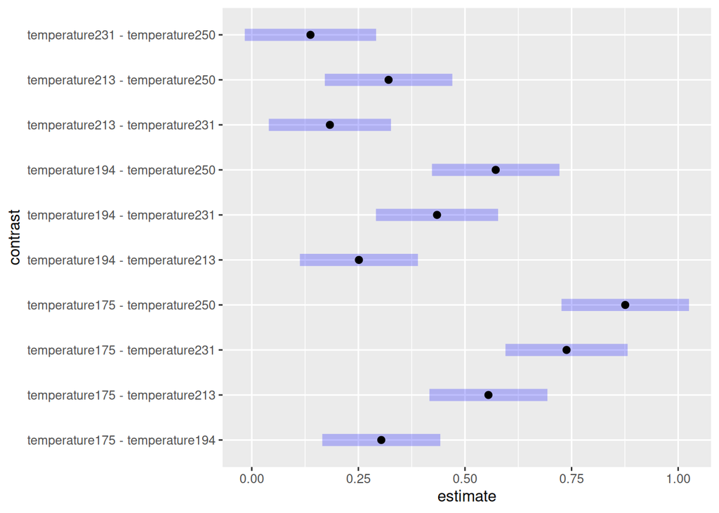

```r
# Plot the pairwise comparisons
plot(pairwise_results)
```

The output will now list every possible combination of temperatures. Because it applies Tukey’s adjustment, you can interpret these results safely, knowing the familywise error rate for the entire set of 10 comparisons is rigorously controlled at $\alpha = 0.05$. This workflow ultimately bridges the gap from the initial omnibus ANOVA F-test to the exact, mathematically sound differences driving your experimental results.